# dataset

Autogenerated data summary from dataMaid

2017-10-21 23:59:08

# Data cleaning summary

The dataset examined has the following dimensions:

| Feature | Result |
| --- | --- |
| Number of rows | 845 |
| Number of variables | 14 |

### Checks performed

The following variable checks were performed, depending on the data type of each variable:

|  | character | factor | labelled | numeric | integer | logical | Date |
| --- | --- | --- | --- | --- | --- | --- | --- |
| Identify miscoded missing values | × | × | × | × | × |  |  |
| Identify prefixed and suffixed whitespace | × | × | × |  |  |  |  |
| Identify levels with < 6 obs. | × | × | × |  |  |  |  |
| Identify case issues | × | × | × |  |  |  |  |
| Identify misclassified numeric or integer variables | × | × | × |  |  |  |  |
| Identify outliers |  |  |  | × | × |  | × |

Please note that all numerical values in the following have been rounded to 2 decimals.

# Summary table

|  | Variable class | # unique values | Missing observations | Any problems? |
| --- | --- | --- | --- | --- |
| ABSOLUTE_LOAD | numeric | 103 | 0.00 % | × |
| ACCELERATOR_POS_D | numeric | 16 | 0.00 % |  |
| ACCELERATOR_POS_E | numeric | 15 | 0.00 % |  |
| BAROMETRIC_PRESSURE | numeric | 1 | 0.00 % | × |
| DISTANCE_W_MIL | numeric | 5 | 0.00 % |  |
| INTAKE_PRESSURE | numeric | 60 | 0.00 % | × |
| INTAKE_TEMP | integer | 21 | 0.00 % | × |
| MAF | numeric | 217 | 0.00 % |  |
| RELATIVE_THROTTLE_POS | numeric | 24 | 0.00 % |  |
| RPM | numeric | 770 | 0.00 % | × |
| RUN_TIME | numeric | 376 | 0.00 % |  |
| SPEED | numeric | 38 | 0.00 % | × |
| THROTTLE_POS | numeric | 23 | 0.00 % |  |
| time | numeric | 845 | 0.00 % |  |

# Variable list

## ABSOLUTE_LOAD

| Feature | Result |
| --- | --- |
| Variable type | numeric |
| Number of missing obs. | 0 (0 %) |
| Number of unique values | 103 |
| Median | 18.82 |
| 1st and 3rd quartiles | 15.69; 27.06 |
| Min. and max. | 8.24; 62.75 |

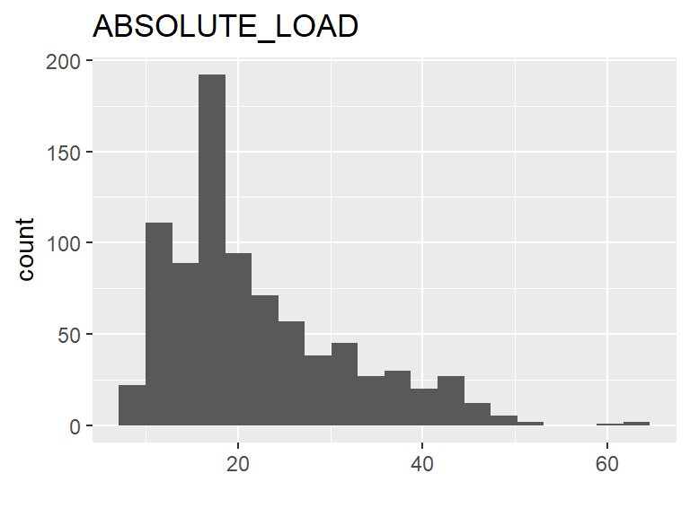

- Note that the following possible outlier values were detected: "8.24", "8.63", "9.02", "9.41", "9.8", "10.2", "10.59", "10.98", "11.37", "11.76" (1 additional values omitted).

## ACCELERATOR_POS_D

| Feature | Result |
| --- | --- |
| Variable type | numeric |
| Number of missing obs. | 0 (0 %) |
| Number of unique values | 16 |
| Median | 32.94 |
| 1st and 3rd quartiles | 31.76; 34.12 |
| Min. and max. | 31.37; 37.65 |

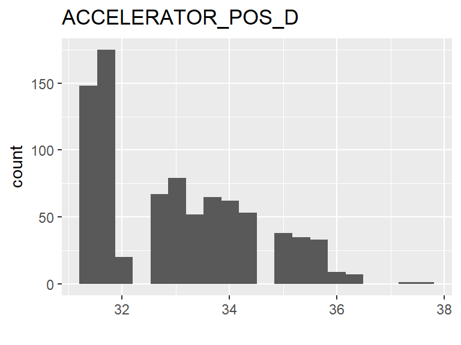

## ACCELERATOR_POS_E

| Feature | Result |
| --- | --- |
| Variable type | numeric |
| Number of missing obs. | 0 (0 %) |
| Number of unique values | 15 |
| Median | 21.57 |
| 1st and 3rd quartiles | 20.78; 22.75 |
| Min. and max. | 20.39; 26.67 |

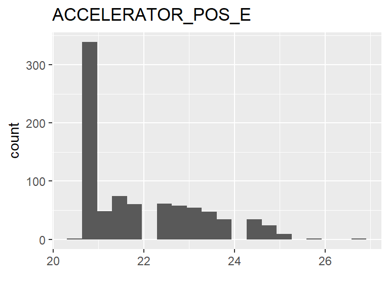

## BAROMETRIC_PRESSURE

- The variable only takes one (non-missing) value: "96". The variable contains 0 % missing observations.

## DISTANCE_W_MIL

- Note that this variable is treated as a factor variable below, as it only takes a few unique values.

| Feature | Result |
| --- | --- |
| Variable type | numeric |
| Number of missing obs. | 0 (0 %) |
| Number of unique values | 5 |
| Mode | “511” |

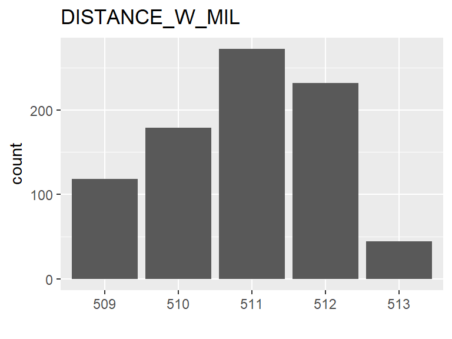

## INTAKE_PRESSURE

| Feature | Result |
| --- | --- |
| Variable type | numeric |
| Number of missing obs. | 0 (0 %) |
| Number of unique values | 60 |
| Median | 28 |
| 1st and 3rd quartiles | 23; 38 |
| Min. and max. | 13; 81 |

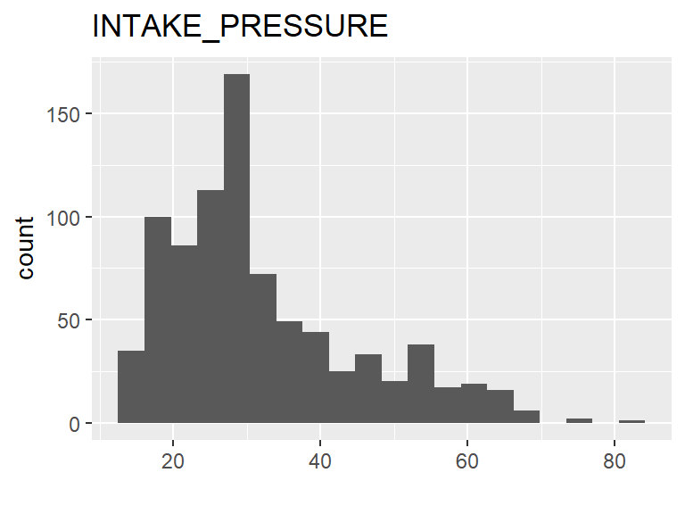

- Note that the following possible outlier values were detected: "13", "14", "15", "16", "17", "18".

## INTAKE_TEMP

| Feature | Result |
| --- | --- |
| Variable type | integer |
| Number of missing obs. | 0 (0 %) |
| Number of unique values | 21 |
| Median | 28 |
| 1st and 3rd quartiles | 25; 30 |
| Min. and max. | 22; 42 |

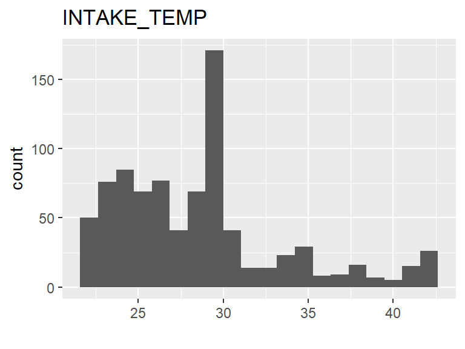

- Note that the following possible outlier values were detected: "38", "39", "40", "41", "42".

## MAF

| Feature | Result |
| --- | --- |
| Variable type | numeric |
| Number of missing obs. | 0 (0 %) |
| Number of unique values | 217 |
| Median | 4.74 |
| 1st and 3rd quartiles | 2.82; 8.39 |
| Min. and max. | 2.12; 21.42 |

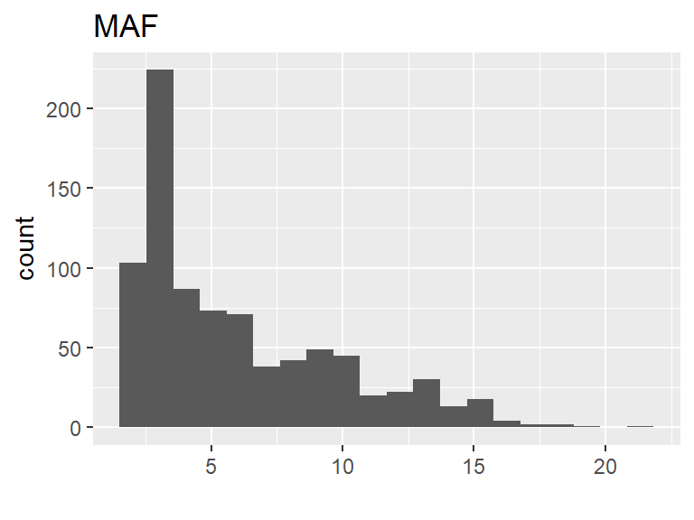

## RELATIVE_THROTTLE_POS

| Feature | Result |
| --- | --- |
| Variable type | numeric |
| Number of missing obs. | 0 (0 %) |
| Number of unique values | 24 |
| Median | 5.49 |
| 1st and 3rd quartiles | 3.92; 7.45 |
| Min. and max. | 3.14; 13.73 |

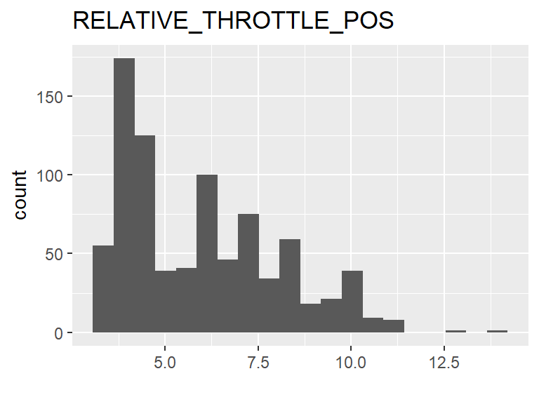

## RPM

| Feature | Result |
| --- | --- |
| Variable type | numeric |
| Number of missing obs. | 0 (0 %) |
| Number of unique values | 770 |
| Median | 1576.5 |
| 1st and 3rd quartiles | 1163; 1869.5 |
| Min. and max. | 634.75; 2899.25 |

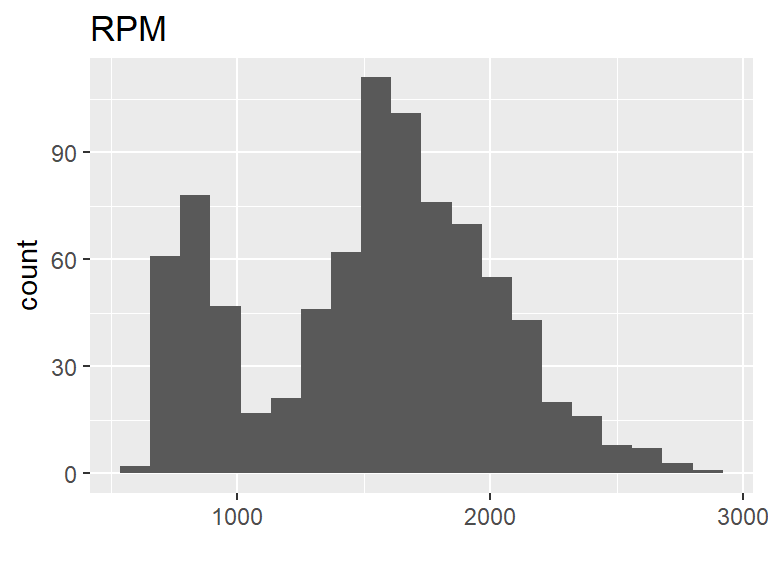

- Note that the following possible outlier values were detected: "2525.25", "2526.75", "2542.75", "2544.25", "2564.75", "2593.5", "2617", "2629.75", "2635.5", "2637.5" (5 additional values omitted).

## RUN_TIME

| Feature | Result |
| --- | --- |
| Variable type | numeric |
| Number of missing obs. | 0 (0 %) |
| Number of unique values | 376 |
| Median | 795 |
| 1st and 3rd quartiles | 638; 936 |
| Min. and max. | 473; 1073 |

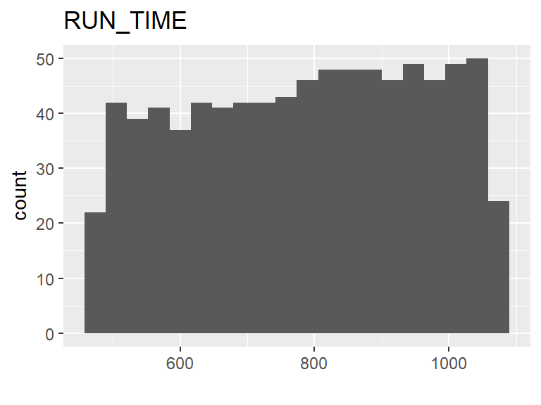

## SPEED

| Feature | Result |
| --- | --- |
| Variable type | numeric |
| Number of missing obs. | 0 (0 %) |
| Number of unique values | 38 |
| Median | 24 |
| 1st and 3rd quartiles | 15; 30 |
| Min. and max. | 0; 38 |

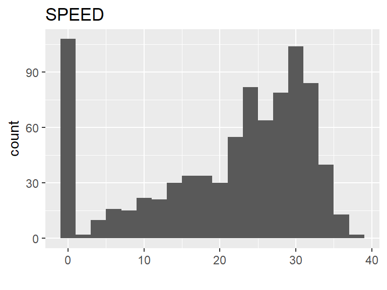

- Note that the following possible outlier values were detected: "36", "37", "38".

## THROTTLE_POS

| Feature | Result |
| --- | --- |
| Variable type | numeric |
| Number of missing obs. | 0 (0 %) |
| Number of unique values | 23 |
| Median | 14.51 |
| 1st and 3rd quartiles | 13.33; 16.47 |
| Min. and max. | 12.55; 21.96 |

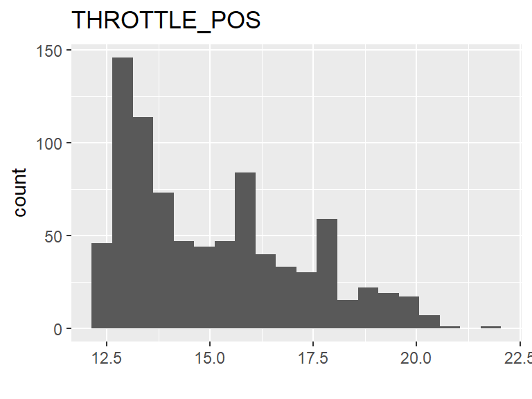

## time

| Feature | Result |
| --- | --- |
| Variable type | numeric |
| Number of missing obs. | 0 (0 %) |
| Number of unique values | 845 |
| Median | 1508611665.92 |
| 1st and 3rd quartiles | 1508611508.22; 1508611806.2 |
| Min. and max. | 1508611344.13; 1508611943.65 |

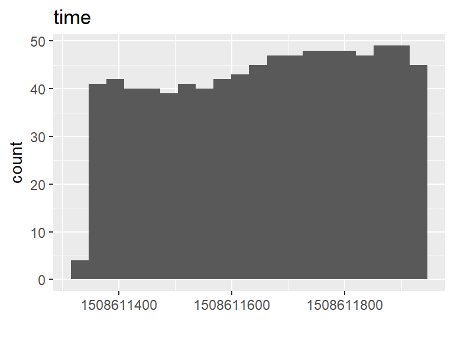

Report generation information:

- Created by Stef Petrov.
- Report creation time: съб окт 21 2017 23:59:07
- dataMaid v0.9.7 [Pkg: 2017-08-31 from Github (ekstroem/dataMaid@560ebb8)]
- R version 3.4.0 (2017-04-21).
- Platform: x86_64-w64-mingw32/x64 (64-bit)(Windows >= 8 x64 (build 9200)).
- Function call: `clean(data = dataset, output = "html", file = "gentle_output.html")`